# HDAT9600 Final Team Assignment

##### Summary of included variables

| Variable | Stats / Values | Freqs (% of Valid) | Graph | Valid | Missing |
| --- | --- | --- | --- | --- | --- |
| Length_of_stay = Number of days from ICU admission to end of hospitalisation [numeric] | Mean (sd) : 13.9 (12.9) min < med < max: 2 < 10 < 154 IQR (CV) : 11 (0.9) | 74 distinct values |  | 2061 (100.0%) | 0 (0.0%) |
| Survival = Number of days between ICU admission and death [numeric] | Mean (sd) : 343.1 (526.9) min < med < max: 0 < 68 < 2408 IQR (CV) : 410 (1.5) | 387 distinct values |  | 773 (37.5%) | 1288 (62.5%) |
| LR_in_hospital_death = In hospital death [factor] | 1. Survived 2. Died | 1764 (85.6%) 297 (14.4%) |  | 2061 (100.0%) | 0 (0.0%) |
| Days = Length of survival (in days) [numeric] | Mean (sd) : 1633.5 (1050.7) min < med < max: 0 < 2408 < 2408 IQR (CV) : 2143 (0.6) | 387 distinct values |  | 2061 (100.0%) | 0 (0.0%) |
| Surv_Status = Survival status [factor] | 1. Survived 2. Died | 1288 (62.5%) 773 (37.5%) |  | 2061 (100.0%) | 0 (0.0%) |
| Age = Age in years [integer] | Mean (sd) : 64.4 (17.5) min < med < max: 16 < 67 < 90 IQR (CV) : 26 (0.3) | 75 distinct values |  | 2061 (100.0%) | 0 (0.0%) |
| ICUType = Type of ICU [factor] | 1. Coronary Care Unit 2. Cardiac Surgery Recovery 3. Medical ICU 4. Surgical ICU | 297 (14.4%) 448 (21.7%) 788 (38.2%) 528 (25.6%) |  | 2061 (100.0%) | 0 (0.0%) |
| SAPS1 = Simplified Acute Physiological Score [integer] | Mean (sd) : 15 (5.2) min < med < max: 1 < 15 < 34 IQR (CV) : 8 (0.3) | 34 distinct values |  | 1965 (95.3%) | 96 (4.7%) |
| SOFA = Sequential Organ Failure Assessment [numeric] | Mean (sd) : 6.7 (4) min < med < max: 0 < 7 < 22 IQR (CV) : 5 (0.6) | 22 distinct values |  | 2061 (100.0%) | 0 (0.0%) |
| Albumin_max = Maximum Albumin (g/dL) [numeric] | Mean (sd) : 3 (0.6) min < med < max: 1.1 < 3 < 5.3 IQR (CV) : 0.9 (0.2) | 37 distinct values |  | 2061 (100.0%) | 0 (0.0%) |
| AST_max = Maximum Aspartate transaminase (IU/L) [numeric] | Mean (sd) : 188.1 (765.8) min < med < max: 5 < 51 < 16040 IQR (CV) : 103 (4.1) | 272 distinct values |  | 2061 (100.0%) | 0 (0.0%) |
| Bilirubin_max = Maximum Bilirubin (mg/dL) [numeric] | Mean (sd) : 1.7 (4.2) min < med < max: 0.1 < 0.7 < 45.9 IQR (CV) : 0.9 (2.4) | 105 distinct values |  | 2061 (100.0%) | 0 (0.0%) |
| BUN_max = Maximum Blood urea nitrogen (mg/dL) [numeric] | Mean (sd) : 27.5 (22.6) min < med < max: 3 < 20 < 197 IQR (CV) : 19 (0.8) | 125 distinct values |  | 2061 (100.0%) | 0 (0.0%) |
| Creatinine_max = Maximum Serum creatinine (mg/dL) [numeric] | Mean (sd) : 1.5 (1.6) min < med < max: 0.2 < 1 < 22 IQR (CV) : 0.7 (1.1) | 97 distinct values |  | 2061 (100.0%) | 0 (0.0%) |
| GCS_max = Maximum Glasgow Coma Score (3-15) [integer] | Mean (sd) : 12.9 (3.1) min < med < max: 3 < 15 < 15 IQR (CV) : 4 (0.2) | 13 distinct values |  | 2061 (100.0%) | 0 (0.0%) |
| Glucose_max = Maximum Serum glucose (mg/dL) [numeric] | Mean (sd) : 163.3 (88.5) min < med < max: 39 < 141 < 1143 IQR (CV) : 63 (0.5) | 314 distinct values |  | 2061 (100.0%) | 0 (0.0%) |
| HCO3_max = Maximum Serum bicarbonate (mmol/L) [numeric] | Mean (sd) : 24.3 (4.2) min < med < max: 9 < 24 < 47 IQR (CV) : 5 (0.2) | 37 distinct values |  | 2061 (100.0%) | 0 (0.0%) |
| HR_diff = Difference between the mean and the most extreme heart rate (bpm) [numeric] | Mean (sd) : 30.4 (15.5) min < med < max: 0.9 < 27.1 < 212.9 IQR (CV) : 16.8 (0.5) | 149 distinct values |  | 2061 (100.0%) | 0 (0.0%) |
| Lactate_max = Maximum Serum Lactate (mmol/L) [numeric] | Mean (sd) : 2.8 (2.2) min < med < max: 0.4 < 2.2 < 29.3 IQR (CV) : 1.7 (0.8) | 112 distinct values |  | 2061 (100.0%) | 0 (0.0%) |
| Na_diff = Difference between the mean and the most extreme Serum sodium (mEq/L) [numeric] | Mean (sd) : 4.1 (3.7) min < med < max: 0.2 < 3.2 < 41.2 IQR (CV) : 3.4 (0.9) | 48 distinct values |  | 2061 (100.0%) | 0 (0.0%) |
| pH_diff = Difference between the mean and the most extreme Arterial pH (0-14) [numeric] | Mean (sd) : 0.1 (0.1) min < med < max: 0 < 0.1 < 4.4 IQR (CV) : 0.1 (1.1) | 72 distinct values |  | 2061 (100.0%) | 0 (0.0%) |
| RespRate_max = Maximum Respiration rate (bpm) [numeric] | Mean (sd) : 29.1 (7.8) min < med < max: 13 < 27 < 98 IQR (CV) : 9 (0.3) | 37 distinct values |  | 2061 (100.0%) | 0 (0.0%) |
| Temp_diff = Difference between the mean and the most extreme Temperature (°C) [numeric] | Mean (sd) : 1.4 (0.8) min < med < max: 0.1 < 1.3 < 12.8 IQR (CV) : 0.9 (0.5) | 85 distinct values |  | 2061 (100.0%) | 0 (0.0%) |
| Urine_max = Maximum Urine output (mL) [numeric] | Mean (sd) : 521.8 (508.5) min < med < max: 0 < 400 < 5000 IQR (CV) : 425 (1) | 306 distinct values |  | 2061 (100.0%) | 0 (0.0%) |
| NISysABP_diff = Difference between the mean and the most extreme Non-invasive systolic arterial blood pressure (mmHg) [numeric] | Mean (sd) : 37.8 (19.5) min < med < max: 0.3 < 34.3 < 157.3 IQR (CV) : 20 (0.5) | 189 distinct values |  | 1608 (78.0%) | 453 (22.0%) |

### Prediction model building for in-hospital death of ICU patients in the USA

```r
icu_patients_df1_reduced <- icu_patients_df1 %>%
                          dplyr::select(in_hospital_death, Age, ICUType,
                                 SAPS1, SOFA, Albumin_max, AST_max, Bilirubin_max, BUN_max, Creatinine_max, GCS_max, Glucose_max, HCO3_max,
                                 HR_diff, Lactate_max, Na_diff, pH_diff, RespRate_max, Temp_diff, Urine_max, NISysABP_diff)

lapply(c(colnames(icu_patients_df1_reduced[-c(1)])),

       function(var) {

           formula    <- as.formula(paste("in_hospital_death ~", var))
           res.logist <- glm(formula, data = icu_patients_df1, family = binomial)

           summary(res.logist)
       })
```

```
## [[1]]
##
## Call:
## glm(formula = formula, family = binomial, data = icu_patients_df1)
##
## Coefficients:
##              Estimate Std. Error z value Pr(>|z|)
## (Intercept) -3.761624   0.303337 -12.401  < 2e-16 ***
## Age          0.029376   0.004229   6.947 3.73e-12 ***
## ---
## Signif. codes:  0 '***' 0.001 '**' 0.01 '*' 0.05 '.' 0.1 ' ' 1
##
## (Dispersion parameter for binomial family taken to be 1)
##
##     Null deviance: 1699.7  on 2060  degrees of freedom
## Residual deviance: 1644.9  on 2059  degrees of freedom
## AIC: 1648.9
##
## Number of Fisher Scoring iterations: 5
##
##
## [[2]]
##
## Call:
## glm(formula = formula, family = binomial, data = icu_patients_df1)
##
## Coefficients:
##                                      Estimate Std. Error z value Pr(>|z|)
## (Intercept)                           -1.6463     0.1576 -10.443  < 2e-16 ***
## ICUTypeCardiac Surgery Recovery Unit  -1.1407     0.2563  -4.451 8.55e-06 ***
## ICUTypeMedical ICU                     0.1653     0.1824   0.906    0.365
## ICUTypeSurgical ICU                   -0.1214     0.2001  -0.607    0.544
## ---
## Signif. codes:  0 '***' 0.001 '**' 0.01 '*' 0.05 '.' 0.1 ' ' 1
##
## (Dispersion parameter for binomial family taken to be 1)
##
##     Null deviance: 1699.7  on 2060  degrees of freedom
## Residual deviance: 1655.3  on 2057  degrees of freedom
## AIC: 1663.3
```

[output cut: 367 more lines]

```
## Coefficients:
##                Estimate Std. Error z value Pr(>|z|)
## (Intercept)   -2.218317   0.149035 -14.885  < 2e-16 ***
## NISysABP_diff  0.013760   0.003197   4.304 1.68e-05 ***
## ---
## Signif. codes:  0 '***' 0.001 '**' 0.01 '*' 0.05 '.' 0.1 ' ' 1
##
## (Dispersion parameter for binomial family taken to be 1)
##
##     Null deviance: 1403.1  on 1607  degrees of freedom
## Residual deviance: 1385.4  on 1606  degrees of freedom
##   (453 observations deleted due to missingness)
## AIC: 1389.4
##
## Number of Fisher Scoring iterations: 4
```

```
##
## Call:
## glm(formula = in_hospital_death ~ Age + ICUType + SAPS1 + SOFA +
##     Albumin_max + AST_max + Bilirubin_max + BUN_max + Creatinine_max +
##     GCS_max + Glucose_max + HCO3_max + HR_diff + Lactate_max +
##     Na_diff + pH_diff + RespRate_max + Temp_diff + Urine_max +
##     NISysABP_diff, family = binomial, data = icu_patients_df1)
##
## Coefficients:
##                                        Estimate Std. Error z value Pr(>|z|)
## (Intercept)                          -2.427e+00  9.924e-01  -2.446 0.014461 *
## Age                                   2.674e-02  5.700e-03   4.691 2.72e-06 ***
## ICUTypeCardiac Surgery Recovery Unit -5.555e-01  3.830e-01  -1.450 0.146977
## ICUTypeMedical ICU                    1.940e-03  2.390e-01   0.008 0.993523
## ICUTypeSurgical ICU                   6.459e-02  2.619e-01   0.247 0.805185
## SAPS1                                 4.717e-02  2.635e-02   1.790 0.073459 .
## SOFA                                  2.875e-02  2.933e-02   0.980 0.327021
## Albumin_max                          -2.638e-01  1.335e-01  -1.975 0.048226 *
## AST_max                               1.195e-04  9.042e-05   1.321 0.186388
## Bilirubin_max                         4.803e-02  1.454e-02   3.303 0.000955 ***
## BUN_max                               1.951e-02  4.381e-03   4.453 8.48e-06 ***
## Creatinine_max                       -1.657e-01  6.816e-02  -2.431 0.015071 *
## GCS_max                              -1.150e-01  2.871e-02  -4.005 6.19e-05 ***
## Glucose_max                           4.608e-06  8.664e-04   0.005 0.995757
## HCO3_max                             -2.144e-02  1.814e-02  -1.182 0.237268
## HR_diff                               6.403e-03  4.698e-03   1.363 0.172896
## Lactate_max                           4.037e-02  3.921e-02   1.030 0.303234
## Na_diff                              -2.597e-03  2.138e-02  -0.121 0.903301
## pH_diff                               8.762e-01  1.066e+00   0.822 0.410999
## RespRate_max                         -1.743e-03  1.057e-02  -0.165 0.869053
## Temp_diff                             2.766e-02  1.058e-01   0.261 0.793838
## Urine_max                            -9.156e-04  2.642e-04  -3.465 0.000530 ***
## NISysABP_diff                         5.926e-03  4.087e-03   1.450 0.147021
## ---
## Signif. codes:  0 '***' 0.001 '**' 0.01 '*' 0.05 '.' 0.1 ' ' 1
##
## (Dispersion parameter for binomial family taken to be 1)
##
##     Null deviance: 1350  on 1550  degrees of freedom
## Residual deviance: 1089  on 1528  degrees of freedom
##   (510 observations deleted due to missingness)
## AIC: 1135
##
## Number of Fisher Scoring iterations: 6
```

```
##
## Call:
## glm(formula = in_hospital_death ~ Age + SAPS1 + Albumin_max +
##     AST_max + Bilirubin_max + BUN_max + Creatinine_max + GCS_max +
##     HCO3_max + HR_diff + pH_diff + Urine_max + NISysABP_diff,
##     family = binomial, data = icu_patients_df1)
##
## Coefficients:
##                  Estimate Std. Error z value Pr(>|z|)
## (Intercept)    -1.966e+00  7.942e-01  -2.476 0.013292 *
## Age             2.549e-02  5.498e-03   4.635 3.56e-06 ***
## SAPS1           5.602e-02  2.005e-02   2.793 0.005218 **
## Albumin_max    -3.038e-01  1.292e-01  -2.350 0.018756 *
## AST_max         1.545e-04  8.703e-05   1.776 0.075771 .
## Bilirubin_max   5.246e-02  1.385e-02   3.788 0.000152 ***
## BUN_max         2.047e-02  4.181e-03   4.896 9.78e-07 ***
## Creatinine_max -1.644e-01  6.685e-02  -2.459 0.013939 *
## GCS_max        -1.272e-01  2.631e-02  -4.835 1.33e-06 ***
## HCO3_max       -2.563e-02  1.776e-02  -1.443 0.148958
## HR_diff         7.585e-03  4.494e-03   1.688 0.091431 .
## pH_diff         1.389e+00  1.203e+00   1.154 0.248302
## Urine_max      -1.000e-03  2.574e-04  -3.886 0.000102 ***
## NISysABP_diff   6.313e-03  3.955e-03   1.596 0.110456
## ---
## Signif. codes:  0 '***' 0.001 '**' 0.01 '*' 0.05 '.' 0.1 ' ' 1
##
## (Dispersion parameter for binomial family taken to be 1)
##
##     Null deviance: 1350.0  on 1550  degrees of freedom
## Residual deviance: 1094.9  on 1537  degrees of freedom
##   (510 observations deleted due to missingness)
## AIC: 1122.9
##
## Number of Fisher Scoring iterations: 5
```

Model 2 should be chosen as significantly lower AIC

Finally, re-fit your final model to the unimputed data frame (`icu_patients_df0.rds`) and comment on any differences you find compared to the same model fitted to the imputed data.

```
##            Age        ICUType          SAPS1           SOFA    Albumin_max
##              0              0             96              0              0
##        AST_max  Bilirubin_max        BUN_max Creatinine_max        GCS_max
##              0              0              0              0              0
##    Glucose_max       HCO3_max        HR_diff    Lactate_max        Na_diff
##              0              0              0              0              0
##        pH_diff   RespRate_max      Temp_diff      Urine_max  NISysABP_diff
##              0              0              0              0            453
```

```
##            Age        ICUType          SAPS1           SOFA    Albumin_max
##              0              0             96              0           1353
##        AST_max  Bilirubin_max        BUN_max Creatinine_max        GCS_max
##           1255           1273             48             49             40
##    Glucose_max       HCO3_max        HR_diff    Lactate_max        Na_diff
##            127             64             37           1071             74
##        pH_diff   RespRate_max      Temp_diff      Urine_max  NISysABP_diff
##            597           1506             39             70            448
```

```
## 'data.frame':    29 obs. of  21 variables:
##  $ Age              : num  56 72 83 79 57 59 73 70 46 72 ...
##  $ ICUType          : Factor w/ 4 levels "Coronary Care Unit",..: 3 3 3 3 4 3 3 3 3 3 ...
##  $ SAPS1            : num  10 16 13 10 13 14 16 10 19 9 ...
##  $ SOFA             : num  9 9 8 10 6 3 2 -1 7 9 ...
##  $ Albumin_max      : num  2.8 2.5 2.9 2.6 3.9 2.8 2.8 2.6 3.6 3.8 ...
##  $ AST_max          : num  83 71 203 145 26 637 211 35 39 19 ...
##  $ Bilirubin_max    : num  6.5 2.9 0.7 3.7 0.3 0.4 0.3 2.8 0.3 0.3 ...
##  $ BUN_max          : num  81 29 64 56 42 45 24 36 36 66 ...
##  $ Creatinine_max   : num  3.2 1.3 3.2 1.8 3.7 4.7 0.9 1.6 2.2 6.2 ...
##  $ GCS_max          : num  15 15 14 15 14 15 15 15 15 15 ...
##  $ Glucose_max      : num  136 214 112 239 151 132 70 73 350 156 ...
##  $ HCO3_max         : num  20 15 23 20 22 20 23 24 17 16 ...
##  $ HR_diff          : num  18.9 17.1 43.9 29.1 27.1 ...
##  $ Lactate_max      : num  3.8 2.2 1.1 1.5 0.8 1.7 1.7 1.9 2.2 1.1 ...
##  $ Na_diff          : num  5.207 2.207 1.793 1.793 0.207 ...
##  $ pH_diff          : num  0.019886 0.069886 0.169886 0.000114 0.040114 ...
##  $ RespRate_max     : num  43 32 28 24 16 27 23 27 40 23 ...
##  $ Temp_diff        : num  1.074 1.874 1.374 0.826 0.474 ...
##  $ Urine_max        : num  260 60 320 200 90 140 540 450 1700 170 ...
##  $ NISysABP_diff    : num  26.7 40.7 44.7 31.7 36.3 ...
##  $ in_hospital_death: num  0 0 1 0 0 0 0 0 0 0 ...
##  - attr(*, "na.action")= 'omit' Named int [1:2032] 1 2 3 4 5 6 7 8 9 10 ...
##   ..- attr(*, "names")= chr [1:2032] "1" "2" "3" "4" ...
```

Note that after removal of missing data, we are down to 29 observations from 2061, which is insufficient for analysis of the required model.It would be better to therefore exclude the variables with significantly missing data as predictors. In this case, I would start by excluding all variables with > 1000 missing dataset:

Therefore, the the following variables should be excluded:

- Albumin_max (1353 missing values)
- AST_max (1255 missing values)
- Bilirubin_max (1273 missing values)
- Lactate_max (1071 missing values)
- RespRate_max (1506 missing values)

This brings down the list of variables to:

-Age -ICUType -SAPS1 -SOFA -GCS_max -Glucose_max -HCO3_max -HR_diff -Na_diff -pH_diff -Temp_diff -Urine_max -NISysABP_diff -BUN_max -Creatinine_max

```
## 'data.frame':    1001 obs. of  16 variables:
##  $ Age              : num  76 44 64 78 71 65 78 40 80 53 ...
##  $ ICUType          : Factor w/ 4 levels "Coronary Care Unit",..: 2 3 1 3 2 3 3 2 4 4 ...
##  $ SAPS1            : num  16 21 14 19 13 18 28 18 22 10 ...
##  $ SOFA             : num  8 11 11 8 7 6 16 7 5 12 ...
##  $ GCS_max          : num  15 8 9 15 15 14 11 15 8 8 ...
##  $ Glucose_max      : num  105 141 264 139 132 341 204 114 201 150 ...
##  $ HCO3_max         : num  22 26 19 18 25 28 19 27 28 22 ...
##  $ HR_diff          : num  7.08 30.08 16.08 25.08 24.92 ...
##  $ Na_diff          : num  0.207 2.207 2.207 1.793 0.793 ...
##  $ pH_diff          : num  0.0801 0.1401 0.0799 0.2599 0.0901 ...
##  $ Temp_diff        : num  2.47 2.03 1.17 1.37 1.47 ...
##  $ Urine_max        : num  770 410 1200 130 2340 360 1900 990 400 350 ...
##  $ NISysABP_diff    : num  44.7 33.3 35.7 40.7 32.7 ...
##  $ BUN_max          : num  18 8 19 81 9 39 21 10 19 33 ...
##  $ Creatinine_max   : num  1.2 0.4 1.4 0.9 0.5 2.5 1.2 0.6 0.8 1 ...
##  $ in_hospital_death: num  0 0 0 1 0 0 0 0 1 0 ...
##  - attr(*, "na.action")= 'omit' Named int [1:5] 75 134 267 328 786
##   ..- attr(*, "names")= chr [1:5] "151" "276" "564" "689" ...
```

```
##
## Call:
## glm(formula = in_hospital_death ~ Age + ICUType + SAPS1 + SOFA +
##     BUN_max + Creatinine_max + GCS_max + Glucose_max + HCO3_max +
##     HR_diff + Na_diff + pH_diff + Temp_diff + Urine_max + NISysABP_diff,
##     family = binomial, data = icu_patients_df0_r_missing_factors)
##
## Coefficients:
##                                        Estimate Std. Error z value Pr(>|z|)
## (Intercept)                          -3.4086562  0.9234713  -3.691 0.000223 ***
## Age                                   0.0308075  0.0066764   4.614 3.94e-06 ***
## ICUTypeCardiac Surgery Recovery Unit -0.7040238  0.4159646  -1.693 0.090549 .
## ICUTypeMedical ICU                   -0.2105871  0.2846318  -0.740 0.459386
## ICUTypeSurgical ICU                  -0.0845355  0.3030817  -0.279 0.780306
## SAPS1                                 0.0325290  0.0313349   1.038 0.299219
## SOFA                                  0.0715249  0.0310680   2.302 0.021324 *
## BUN_max                               0.0206315  0.0052629   3.920 8.85e-05 ***
## Creatinine_max                       -0.1873086  0.0819414  -2.286 0.022261 *
## GCS_max                              -0.1060981  0.0295220  -3.594 0.000326 ***
## Glucose_max                           0.0004420  0.0010136   0.436 0.662811
## HCO3_max                             -0.0289266  0.0200551  -1.442 0.149201
## HR_diff                               0.0068137  0.0052523   1.297 0.194535
## Na_diff                              -0.0002218  0.0253658  -0.009 0.993022
## pH_diff                               1.6285606  1.3706409   1.188 0.234765
## Temp_diff                             0.0164961  0.1139418   0.145 0.884887
## Urine_max                            -0.0008120  0.0002835  -2.865 0.004173 **
## NISysABP_diff                         0.0074347  0.0047615   1.561 0.118425
## ---
## Signif. codes:  0 '***' 0.001 '**' 0.01 '*' 0.05 '.' 0.1 ' ' 1
##
## (Dispersion parameter for binomial family taken to be 1)
##
##     Null deviance: 964.10  on 1000  degrees of freedom
## Residual deviance: 775.92  on  983  degrees of freedom
## AIC: 811.92
##
## Number of Fisher Scoring iterations: 5
```

```
##
## Call:
## glm(formula = in_hospital_death ~ Age + SOFA + BUN_max + Creatinine_max +
##     GCS_max + HCO3_max + HR_diff + pH_diff + Urine_max + NISysABP_diff,
##     family = binomial, data = icu_patients_df0_r_missing_factors)
##
## Coefficients:
##                  Estimate Std. Error z value Pr(>|z|)
## (Intercept)    -3.2403691  0.8441035  -3.839 0.000124 ***
## Age             0.0330981  0.0062716   5.277 1.31e-07 ***
## SOFA            0.0830704  0.0273446   3.038 0.002382 **
## BUN_max         0.0218322  0.0050926   4.287 1.81e-05 ***
## Creatinine_max -0.1881034  0.0813929  -2.311 0.020830 *
## GCS_max        -0.1235425  0.0283654  -4.355 1.33e-05 ***
## HCO3_max       -0.0283252  0.0199668  -1.419 0.156010
## HR_diff         0.0091917  0.0049709   1.849 0.064442 .
## pH_diff         2.0254765  1.3411192   1.510 0.130970
## Urine_max      -0.0008456  0.0002762  -3.061 0.002205 **
## NISysABP_diff   0.0095928  0.0044970   2.133 0.032912 *
## ---
## Signif. codes:  0 '***' 0.001 '**' 0.01 '*' 0.05 '.' 0.1 ' ' 1
##
## (Dispersion parameter for binomial family taken to be 1)
##
##     Null deviance: 964.1  on 1000  degrees of freedom
## Residual deviance: 781.3  on  990  degrees of freedom
## AIC: 803.3
##
## Number of Fisher Scoring iterations: 5
```

```
##               Age           ICUType             SAPS1              SOFA
##                 0                 0                 0                 0
##           GCS_max       Glucose_max          HCO3_max           HR_diff
##                 0                 0                 0                 0
##           Na_diff           pH_diff         Temp_diff         Urine_max
##                 0                 0                 0                 0
##     NISysABP_diff           BUN_max    Creatinine_max in_hospital_death
##                 0                 0                 0                 0
```

```
##
## Call:
## glm(formula = in_hospital_death ~ Age + ICUType + SAPS1 + SOFA +
##     BUN_max + Creatinine_max + GCS_max + Glucose_max + HCO3_max +
##     HR_diff + Na_diff + pH_diff + Temp_diff + Urine_max + NISysABP_diff,
##     family = binomial, data = icu_patients_df0_r_missing_factors)
##
## Coefficients:
##                                        Estimate Std. Error z value Pr(>|z|)
## (Intercept)                          -3.4086562  0.9234713  -3.691 0.000223 ***
## Age                                   0.0308075  0.0066764   4.614 3.94e-06 ***
## ICUTypeCardiac Surgery Recovery Unit -0.7040238  0.4159646  -1.693 0.090549 .
## ICUTypeMedical ICU                   -0.2105871  0.2846318  -0.740 0.459386
## ICUTypeSurgical ICU                  -0.0845355  0.3030817  -0.279 0.780306
## SAPS1                                 0.0325290  0.0313349   1.038 0.299219
## SOFA                                  0.0715249  0.0310680   2.302 0.021324 *
## BUN_max                               0.0206315  0.0052629   3.920 8.85e-05 ***
## Creatinine_max                       -0.1873086  0.0819414  -2.286 0.022261 *
## GCS_max                              -0.1060981  0.0295220  -3.594 0.000326 ***
## Glucose_max                           0.0004420  0.0010136   0.436 0.662811
## HCO3_max                             -0.0289266  0.0200551  -1.442 0.149201
## HR_diff                               0.0068137  0.0052523   1.297 0.194535
## Na_diff                              -0.0002218  0.0253658  -0.009 0.993022
## pH_diff                               1.6285606  1.3706409   1.188 0.234765
## Temp_diff                             0.0164961  0.1139418   0.145 0.884887
## Urine_max                            -0.0008120  0.0002835  -2.865 0.004173 **
## NISysABP_diff                         0.0074347  0.0047615   1.561 0.118425
## ---
## Signif. codes:  0 '***' 0.001 '**' 0.01 '*' 0.05 '.' 0.1 ' ' 1
##
## (Dispersion parameter for binomial family taken to be 1)
##
##     Null deviance: 964.10  on 1000  degrees of freedom
## Residual deviance: 775.92  on  983  degrees of freedom
## AIC: 811.92
##
## Number of Fisher Scoring iterations: 5
```

```
##
## Call:
## glm(formula = in_hospital_death ~ Age + SOFA + BUN_max + Creatinine_max +
##     GCS_max + HCO3_max + HR_diff + pH_diff + Urine_max + NISysABP_diff,
##     family = binomial, data = icu_patients_df0_r_missing_factors)
##
## Coefficients:
##                  Estimate Std. Error z value Pr(>|z|)
## (Intercept)    -3.2403691  0.8441035  -3.839 0.000124 ***
## Age             0.0330981  0.0062716   5.277 1.31e-07 ***
## SOFA            0.0830704  0.0273446   3.038 0.002382 **
## BUN_max         0.0218322  0.0050926   4.287 1.81e-05 ***
## Creatinine_max -0.1881034  0.0813929  -2.311 0.020830 *
## GCS_max        -0.1235425  0.0283654  -4.355 1.33e-05 ***
## HCO3_max       -0.0283252  0.0199668  -1.419 0.156010
## HR_diff         0.0091917  0.0049709   1.849 0.064442 .
## pH_diff         2.0254765  1.3411192   1.510 0.130970
## Urine_max      -0.0008456  0.0002762  -3.061 0.002205 **
## NISysABP_diff   0.0095928  0.0044970   2.133 0.032912 *
## ---
## Signif. codes:  0 '***' 0.001 '**' 0.01 '*' 0.05 '.' 0.1 ' ' 1
##
## (Dispersion parameter for binomial family taken to be 1)
##
##     Null deviance: 964.1  on 1000  degrees of freedom
## Residual deviance: 781.3  on  990  degrees of freedom
## AIC: 803.3
##
## Number of Fisher Scoring iterations: 5
```

```
##
## Call:
## glm(formula = in_hospital_death ~ Age + SOFA + BUN_max + Creatinine_max +
##     GCS_max + Urine_max + NISysABP_diff, family = binomial, data = icu_patients_df0_r_missing_factors)
##
## Coefficients:
##                  Estimate Std. Error z value Pr(>|z|)
## (Intercept)    -3.5279860  0.6396008  -5.516 3.47e-08 ***
## Age             0.0317480  0.0062247   5.100 3.39e-07 ***
## SOFA            0.1105194  0.0254307   4.346 1.39e-05 ***
## BUN_max         0.0216644  0.0050324   4.305 1.67e-05 ***
## Creatinine_max -0.1700361  0.0791150  -2.149  0.03162 *
## GCS_max        -0.1279980  0.0281059  -4.554 5.26e-06 ***
## Urine_max      -0.0008451  0.0002717  -3.111  0.00187 **
## NISysABP_diff   0.0102667  0.0043954   2.336  0.01950 *
## ---
## Signif. codes:  0 '***' 0.001 '**' 0.01 '*' 0.05 '.' 0.1 ' ' 1
##
## (Dispersion parameter for binomial family taken to be 1)
##
##     Null deviance: 964.10  on 1000  degrees of freedom
## Residual deviance: 791.16  on  993  degrees of freedom
## AIC: 807.16
##
## Number of Fisher Scoring iterations: 5
```

```
## [1] 0.1211097
```

# Task 2

### Part A: Exploratory Data Analysis

```
##
## FALSE  TRUE
##  1288   773
```

```
##
##     FALSE      TRUE
## 0.6249393 0.3750607
```

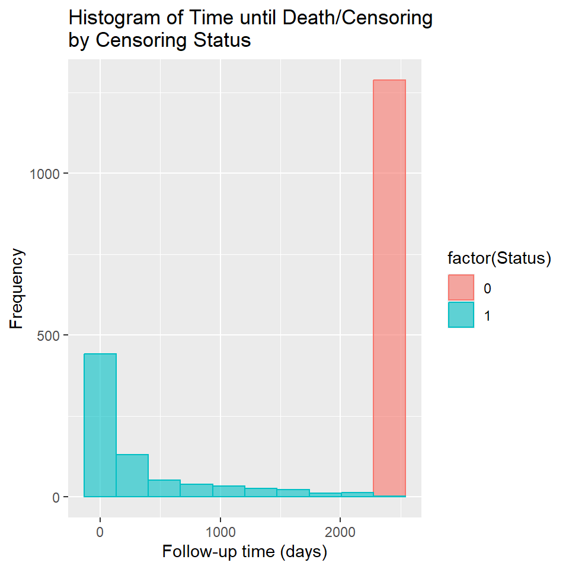

```
## Call: survfit(formula = Surv(Days, Status) ~ 1, data = icu_patients_df1)
##
##         n events median 0.95LCL 0.95UCL
## [1,] 2061    773     NA      NA      NA
```

```
## Call:
## coxph(formula = Surv(Days, Status) ~ Age, data = icu_patients_df1)
##
##   n= 2061, number of events= 773
##
##        coef exp(coef) se(coef)     z Pr(>|z|)
## Age 0.03355   1.03412  0.00250 13.42   <2e-16 ***
## ---
## Signif. codes:  0 '***' 0.001 '**' 0.01 '*' 0.05 '.' 0.1 ' ' 1
##
##     exp(coef) exp(-coef) lower .95 upper .95
## Age     1.034      0.967     1.029     1.039
##
## Concordance= 0.646  (se = 0.01 )
## Likelihood ratio test= 209.4  on 1 df,   p=<2e-16
## Wald test            = 180.1  on 1 df,   p=<2e-16
## Score (logrank) test = 187  on 1 df,   p=<2e-16
```

```
## Call:
## coxph(formula = Surv(Days, Status) ~ Albumin_max, data = icu_patients_df1)
##
##   n= 2061, number of events= 773
##
##                 coef exp(coef) se(coef)      z Pr(>|z|)
## Albumin_max -0.20077   0.81810  0.05745 -3.495 0.000475 ***
## ---
## Signif. codes:  0 '***' 0.001 '**' 0.01 '*' 0.05 '.' 0.1 ' ' 1
##
##             exp(coef) exp(-coef) lower .95 upper .95
## Albumin_max    0.8181      1.222     0.731    0.9156
##
## Concordance= 0.537  (se = 0.011 )
## Likelihood ratio test= 12.26  on 1 df,   p=5e-04
## Wald test            = 12.21  on 1 df,   p=5e-04
## Score (logrank) test = 12.23  on 1 df,   p=5e-04
```

```
## Call:
## coxph(formula = Surv(Days, Status) ~ ICUType, data = icu_patients_df1)
##
##   n= 2061, number of events= 773
##
##                                          coef exp(coef) se(coef)      z
## ICUTypeCardiac Surgery Recovery Unit -0.87895   0.41522  0.13301 -6.608
## ICUTypeMedical ICU                    0.09362   1.09815  0.10131  0.924
## ICUTypeSurgical ICU                  -0.39843   0.67137  0.11603 -3.434
##                                      Pr(>|z|)
## ICUTypeCardiac Surgery Recovery Unit 3.89e-11 ***
## ICUTypeMedical ICU                   0.355437
## ICUTypeSurgical ICU                  0.000595 ***
## ---
## Signif. codes:  0 '***' 0.001 '**' 0.01 '*' 0.05 '.' 0.1 ' ' 1
##
##                                      exp(coef) exp(-coef) lower .95 upper .95
## ICUTypeCardiac Surgery Recovery Unit    0.4152     2.4084    0.3199    0.5389
## ICUTypeMedical ICU                      1.0981     0.9106    0.9004    1.3394
## ICUTypeSurgical ICU                     0.6714     1.4895    0.5348    0.8428
##
## Concordance= 0.597  (se = 0.009 )
## Likelihood ratio test= 98.74  on 3 df,   p=<2e-16
## Wald test            = 87.96  on 3 df,   p=<2e-16
## Score (logrank) test = 93.02  on 3 df,   p=<2e-16
```